# Prior Sensitivity of Null Hypothesis Bayesian Testing in the context of Two-level Models

## Introduction

- **N**ull **H**ypothesis **S**ignificance **T**esting (Cohen, 1994);
- **N**ull **H**ypothesis **B**ayesian **T**esting (Tendeiro & Kiers, 2019);
- Multilevel (Two-level) Models (Hox, Moerbeek, & Van de Schoot, 2017);
- Prior sensitivity (Hoijtink, 2021);
- A predecessor paper that only “sets the stage” for the Master’s Thesis.

[figure not shown]

## Bayes Factor

- The **Bayes Factor** (Kass & Raftery, 1995) is defined as the ratio of two marginal likelihoods.
- Tendeiro & Kiers (2019) define the marginal likelihood as: “*…weighted average of the likelihood over the observed data, where the weights are provided by the (within) priors*.”

\[ \begin{aligned} BF_{0,1} = \frac{P(D|H_0)}{P(D|H_1)} = \frac{\int P(D|\theta_{H_0}, H_0) P(\theta|H_0) d\theta_{H_0}}{\int P(D|\theta_{H_1}, H_1) P(\theta|H_1) d\theta_{H_1}}\ where, \\ \frac{P(H_0|D)}{P(H_1|D)} = BF_{0,1} * \frac{P(H_0)}{P(H_1)}. \end{aligned} \]

- **Conclusion:** The prior distribution influences the marginal likelihood and consequently the value of the BF (when testing *null* hypotheses).

[figure not shown]

## Approximated Adjusted Fractional Bayes Factor

\[ \begin{aligned} AAFBF_{0u} = \frac{f_0}{c_0} = \frac{\int_{\theta \in \Theta_0}\mathcal{N}(\boldsymbol{\hat{\theta}},\boldsymbol{\hat{\Sigma_{\theta}}})d\theta}{\int_{\theta \in \Theta_0}\mathcal{N}(0,\boldsymbol{\hat{\Sigma_{\theta}}}/b)d\theta}\ where,\ b = \frac{J}{N}. \end{aligned} \]

- \(N\) represents the sample size;
- \(J\) by *default* denotes the number of independent constraints in a hypothesis;
- \(\boldsymbol{\hat{\theta}}\) represents the vector of estimated parameters (usually obtained by using some form of MLE) and \(\boldsymbol{\hat{\Sigma_{\theta}}}\) represents it’s respective covariance matrix.
- The AAFBF is defined as the ratio of the *fit* (\(f_0\)) and *comlexity* (\(c_0\)) of a hypothesis against the *uconstrained* hypothesis.
- When testing *null* hypotheses **fit** represents the density of the *posterior* distribution supported by the hypothesis at hand; and the **complexity** represents the density of the **prior** distribution supported by the hypothesis at hand (Hoijtink, Mulder, Lissa, & Gu, 2019).

## Software

- The `R` package `bain` computes AAFBF’s (Gu, Hoijtink, Mulder, & van Lissa, 2021).
- `Wrapper function` programmed specifically for the aims of these papers with which one can test hypotheses about the **fixed** effects of two-level models, using `bain`.

```r
library(lme4) #for fitting multilevel models
library(bain) #the wrapper function does not work without loading bain
source("wrapper_function.R") # load the wrapper function

model<- lmer(y ~ x1 + x2 + (x1 | factor), REML = FALSE, data = dat) #fit a two-level model

hypotheses <- "x1=x2=0; x1=x2; x1>0 & x2>0" #define the hypotheses

bain_2lmer(model, hypotheses, fraction = 1,
           standardize = TRUE, N = "level_2", seed = 123) #use the wrapper function
```

**Two additional questions while programming the function**:

- Standardization (within group, overall)?
- Sample size (level 1 obs, level 2 obs, effective sample size)?

## Sensitivity Analysis

### **The Data**

- `Tutorial` data set (Zhang, Parker, Charlton, Leckie, & Browne, 2016).
- 4059 students within 65 schools.

|  | School | Examscore | LRTscore | AvsLRT |
| --- | --- | --- | --- | --- |
| 1 | 1 | 0.26132 | 0.61906 | 0.16617 |
| 2 | 1 | 0.13407 | 0.2058 | 0.16617 |
| 3 | 1 | -1.7239 | -1.3646 | 0.16617 |
| 4 | 1 | 0.96759 | 0.2058 | 0.16617 |
| 5 | 1 | 0.54434 | 0.3711 | 0.16617 |
| 6 | 1 | 1.7349 | 2.1894 | 0.16617 |
| 7 | 1 | 1.0396 | -1.1166 | 0.16617 |
| 8 | 1 | -0.12908 | -1.034 | 0.16617 |
| 9 | 1 | -0.93938 | -0.53806 | 0.16617 |
| 10 | 1 | -1.2195 | -1.4472 | 0.16617 |

[output cut: 4049 more lines]

**Descriptive statistics:**

| **Characteristic** | **N = 4,059**<sup>1</sup> |
| --- | --- |
| Examscore | 0.00 (-0.70, 0.68) |
| LRTscore | 0.04 (-0.62, 0.62) |
| AvsLRT | -0.02 (-0.15, 0.21) |

<sup>*1*</sup> Median (IQR)

### ….. **Model Specification:**

\(Exam\;score_{ij} = \gamma_{00} + \gamma_{10}LRT\;score_{ij}+\)

\(\gamma_{01}AvgLRT_{j} + u_{1j}LRT\;score_{ij} + u_{0j} + e_{ij}.\)

And \(\boldsymbol{U}\sim \mathcal{N}(\boldsymbol{\mu}, \boldsymbol{\Sigma}),\) \(e_{ij} \sim \mathcal{N}(0, \sigma^2_e).\)

Where: \(\boldsymbol{U} = \{u_{1j}, u_{0j}\},\)

\(\boldsymbol{\mu} =\begin{pmatrix}0 \\0 \;\end{pmatrix},\) \(\boldsymbol{\Sigma} =\begin{pmatrix}\sigma^2_{u1} & \sigma^2_{u1,u0} \\\sigma^2_{u1,u0} &\sigma^2_{u0}\end{pmatrix}\).

### ………………. **Model Fit:**

| Observations | 4059 |
| --- | --- |
| Dependent variable | Examscore |
| Type | Mixed effects linear regression |

| AIC | 9324.40 |
| --- | --- |
| BIC | 9368.56 |
| Pseudo-R² (fixed effects) | 0.35 |
| Pseudo-R² (total) | 0.44 |

| Fixed Effects | Fixed Effects Est. | Fixed Effects S.E. | Fixed Effects t val. | Fixed Effects d.f. | Fixed Effects p |
| --- | --- | --- | --- | --- | --- |
| (Intercept) | -0.00 | 0.04 | -0.03 | 58.92 | 0.97 |
| LRTscore | 0.55 | 0.02 | 27.38 | 57.01 | 0.00 |
| AvsLRT | 0.29 | 0.11 | 2.79 | 65.71 | 0.01 |

p values calculated using Satterthwaite d.f.

| Random Effects Group | Random Effects Parameter | Random Effects Std. Dev. |
| --- | --- | --- |
| School | (Intercept) | 0.27 |
| School | LRTscore | 0.12 |
| Residual |  | 0.74 |

| Grouping Variables Group | Grouping Variables # groups | Grouping Variables ICC |
| --- | --- | --- |
| School | 65 | 0.12 |

## Sensitivity

### **Hypotheses:**

\(H_{0_1}:\gamma_{10} = \gamma_{01} = 0\);

\(H_{0_2}: \gamma_{10} = \gamma_{01}\);

\(H_{i}: \gamma_{10} >0\).

### **Procedure:**

First use the *default* value for `fraction = 1` (i.e., \(1*b\)). Where \(b = \frac{2}{65}=0.03\).

Iteratively change the value of `fraction` to `2, 3, 4`, respectively.

Compare the resulting values for *complexity* and \(BF_{.u}\)

### **Results**

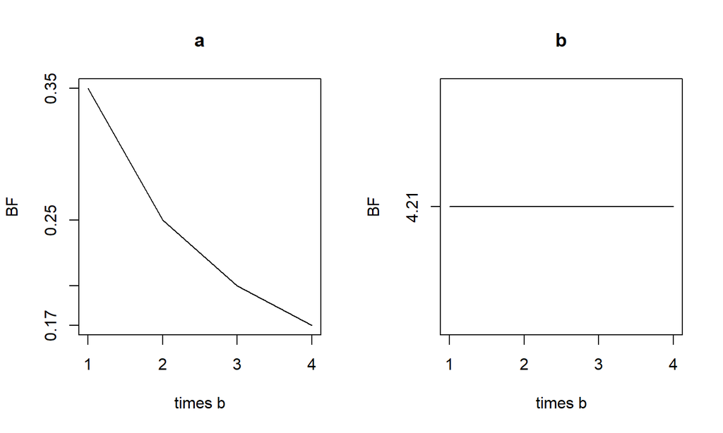

The BF’s of the null hypothesis (a) and informative hypothesis (b) for different values of *b*

## Discussion

In the **Master’s Thesis** the following issues will be adressed:

- Calculating a *reference* value for *J* (and thus for *b*) for Two-level Models, based on the work by Hoijtink (2021) (in which this has been done for Linear Regression, ANCOVA and the Welch Test).
- A new method for calculating the *effective sample size* in two-level models containing random slopes.
  - Comparison between this method and other approaches (such as the regular *ICC-based* effective sample size; number of level 1 observations or number of level 2 observations).
- A discussion on different methods for (data) standardization.
- A simulation study that tests the impact of different combinations of these approaches on the resulting BF’s (calculated using the derived reference value for *J*).

[figure not shown]

## References

Cohen, J. (1994). The earth is round (p<. 05). *American Psychologist*, *49*, 997.

Gu, X., Hoijtink, H., Mulder, J., & van Lissa, C. J. (2021). *Bain: Bayes factors for informative hypotheses*. Retrieved from https://CRAN.R-project.org/package=bain

Hoijtink, H. (2021). Prior sensitivity of null hypothesis bayesian testing. *Psychological Methods*.

Hoijtink, H., Mulder, J., Lissa, C. van, & Gu, X. (2019). A tutorial on testing hypotheses using the bayes factor. *Psychological Methods*, *24*, 539.

Hox, J. J., Moerbeek, M., & Van de Schoot, R. (2017). *Multilevel analysis: Techniques and applications*. Routledge.

Kass, R. E., & Raftery, A. E. (1995). Bayes factors. *Journal of the American Statistical Association*, *90*, 773–795.

Tendeiro, J. N., & Kiers, H. A. (2019). A review of issues about null hypothesis bayesian testing. *Psychological Methods*, *24*, 774.

Zhang, Z., Parker, R. M. A., Charlton, C. M. J., Leckie, G., & Browne, W. J. (2016). R2MLwiN: A package to run MLwiN from within R. *Journal of Statistical Software*, *72*, 1–43.